# Lab5

Tejaswini Sengaonkar

2023-09-26

```r
library(MASS)
library(e1071)
library(class)
library(parallel)
library(rpart)
```

**Introduction**

1. In your own words, describe briefly the data and the practical problem that is associated with the data.

```r
Abalone = read.csv("/course/data/abalone/abalone.csv", strings=TRUE)
Abalone2 = transform(Abalone, class=cut(rings, c(0,8,12,Inf), include=TRUE))
Abalone2[sample(nrow(Abalone), 10),]
```

```
##      sex length diameter height  whole shucked viscera  shell rings    class
## 818    F  0.520    0.395  0.180 0.6400  0.1580  0.1100 0.2450    22 (12,Inf]
## 101    I  0.490    0.375  0.125 0.5445  0.2790  0.1150 0.1300     8    [0,8]
## 181    F  0.675    0.545  0.195 1.7345  0.6845  0.3695 0.6050    20 (12,Inf]
## 4016   I  0.440    0.310  0.115 0.3625  0.1340  0.0820 0.1200    11   (8,12]
## 2298   M  0.615    0.475  0.205 1.3370  0.5995  0.2815 0.3700    11   (8,12]
## 2657   I  0.430    0.330  0.095 0.3200  0.1180  0.0650 0.1230     7    [0,8]
## 1024   F  0.570    0.420  0.160 0.8875  0.4315  0.1915 0.2230     8    [0,8]
## 2671   I  0.280    0.205  0.055 0.1135  0.0450  0.0275 0.0335     7    [0,8]
## 3179   I  0.625    0.430  0.175 1.4110  0.5720  0.2970 0.3950    12   (8,12]
## 1462   M  0.375    0.280  0.095 0.2225  0.0875  0.0430 0.0800    10   (8,12]
```

```r
summary(Abalone)
```

```
##  sex          length         diameter          height           whole
##  F:1307   Min.   :0.075   Min.   :0.0550   Min.   :0.0000   Min.   :0.0020
##  I:1342   1st Qu.:0.450   1st Qu.:0.3500   1st Qu.:0.1150   1st Qu.:0.4415
##  M:1528   Median :0.545   Median :0.4250   Median :0.1400   Median :0.7995
##           Mean   :0.524   Mean   :0.4079   Mean   :0.1395   Mean   :0.8287
##           3rd Qu.:0.615   3rd Qu.:0.4800   3rd Qu.:0.1650   3rd Qu.:1.1530
##           Max.   :0.815   Max.   :0.6500   Max.   :1.1300   Max.   :2.8255
##     shucked          viscera           shell            rings
##  Min.   :0.0010   Min.   :0.0005   Min.   :0.0015   Min.   : 1.000
##  1st Qu.:0.1860   1st Qu.:0.0935   1st Qu.:0.1300   1st Qu.: 8.000
##  Median :0.3360   Median :0.1710   Median :0.2340   Median : 9.000
##  Mean   :0.3594   Mean   :0.1806   Mean   :0.2388   Mean   : 9.934
##  3rd Qu.:0.5020   3rd Qu.:0.2530   3rd Qu.:0.3290   3rd Qu.:11.000
##  Max.   :1.4880   Max.   :0.7600   Max.   :1.0050   Max.   :29.000
```

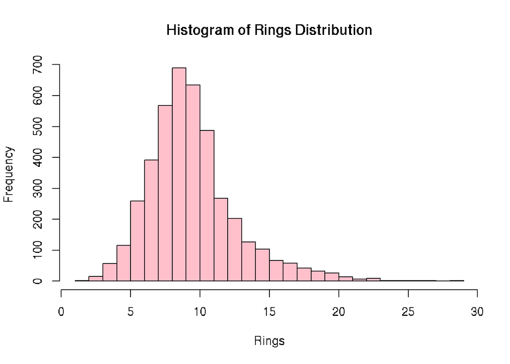

```r
hist(Abalone$rings, breaks = 20, main = "Histogram of Rings Distribution",xlab = "Rings", ylab = "Frequency", col = "pink", border = "black")
```

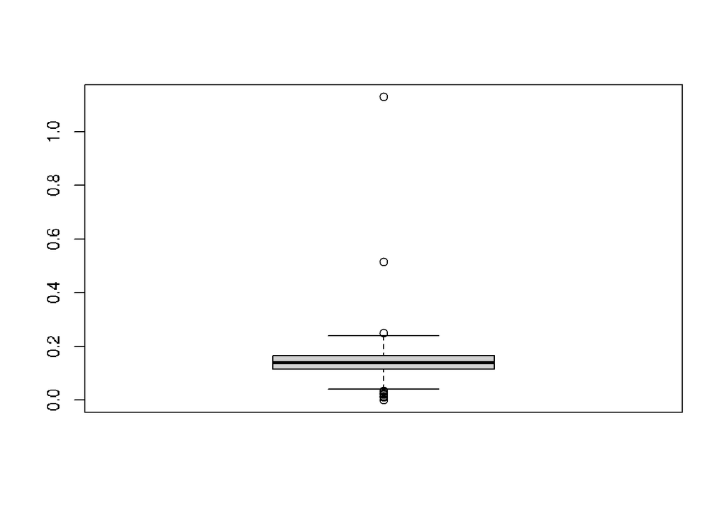

```r
boxplot(Abalone$height)
```

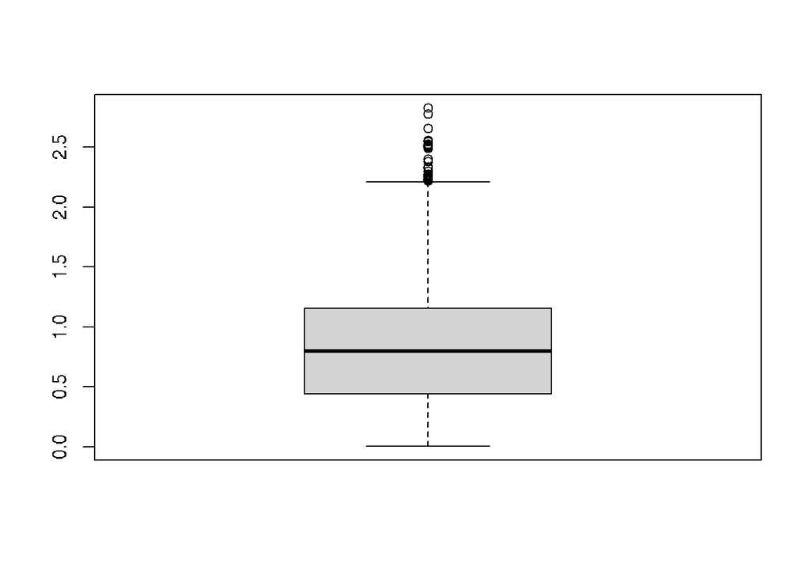

```r
boxplot(Abalone$whole)
```

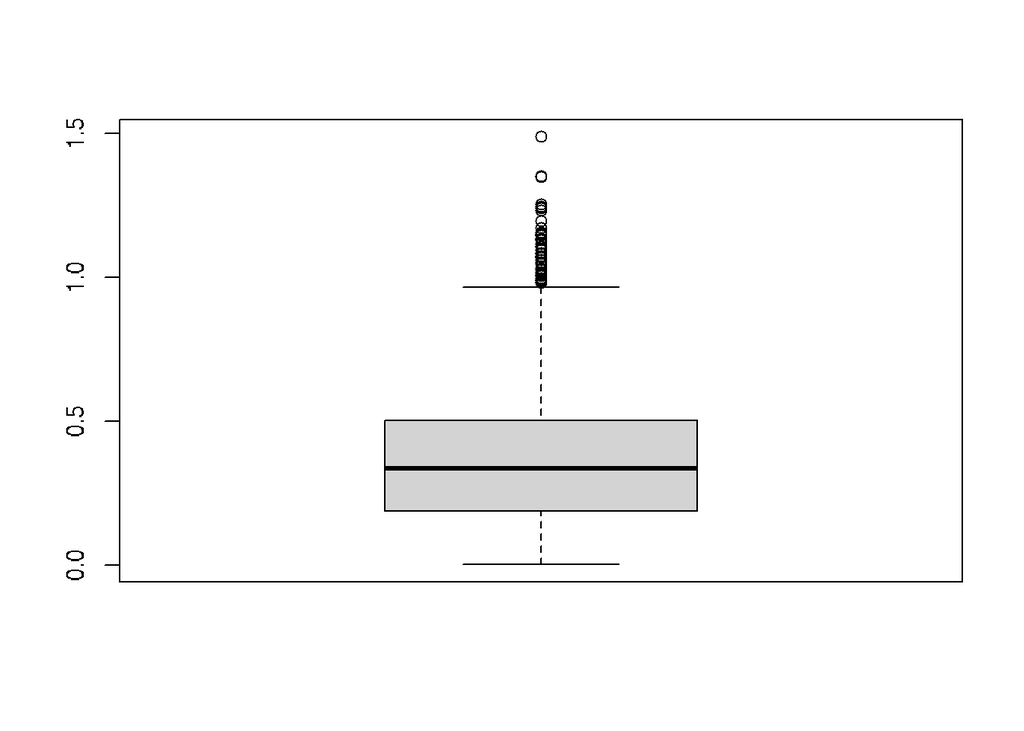

```r
boxplot(Abalone$shucked)
```

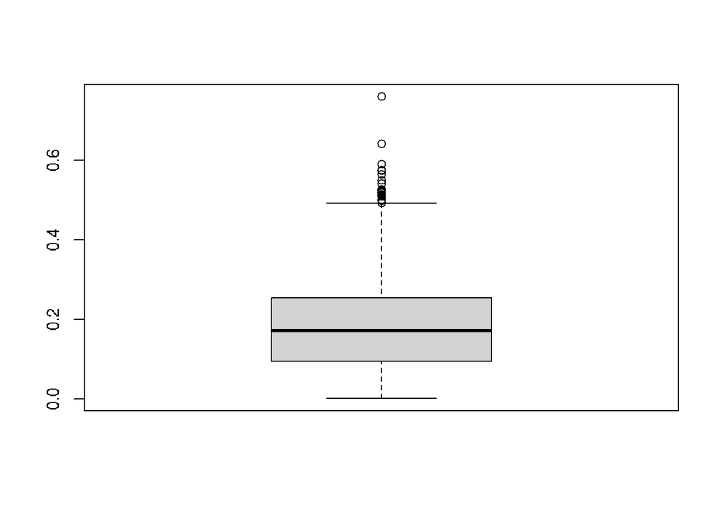

```r
boxplot(Abalone$viscera)
```

According to the data dictionary, it is evident that there is a requirement to standardize or normalize the numerical attributes such as length, diameter, height, whole, etc. This standardization ensures that all features are measured on a consistent scale. Additionally, it’s apparent from the histogram of the “rings” variable that it exhibits right-skewness, indicating that its distribution is not symmetric.

Furthermore, when examining the boxplots for the variables height, whole, shucked, and viscera, we can observe the presence of outliers in these features. These outliers represent data points that deviate significantly from the majority of the data and may warrant special consideration in our analysis.

**Classification and Data Resampling**

2. For the training and test sets, compute the confusion matrix and misclassification rate, using, respectively:
1. Linear discriminant analysis
2. The Naive Bayes method

```
##           Predicted
## Truth      [0,8] (8,12] (12,Inf]
##   [0,8]      239     95        0
##   (8,12]      58    413       33
##   (12,Inf]     7     81       74
```

```
##           Predicted
## Truth      [0,8] (8,12] (12,Inf]
##   [0,8]      772    297        4
##   (8,12]     219   1255       99
##   (12,Inf]    32    295      204
```

```
## [1] 0.726
```

```
## [1] 0.7022348
```

```
##           Predicted
## Truth      [0,8] (8,12] (12,Inf]
##   [0,8]      275     53        6
##   (8,12]     101    290      113
##   (12,Inf]    15     72       75
```

```
##           Predicted
## Truth      [0,8] (8,12] (12,Inf]
##   [0,8]      854    207       12
##   (8,12]     358    794      421
##   (12,Inf]    72    273      186
```

```
## [1] 0.64
```

```
## [1] 0.5772742
```

3. In order to use the K-nearest-neighbour (KNN) method, we need to convert any categorical variable (factor) into dummy binary ones and should also better standardise each variable (to have mean 0 and variance 1).Compute the training and test misclassification rates for K=1,2,…,30.

```r
X <- scale(model.matrix(class ~ . - rings, data = Abalone2)[, -1])

X_train <- X[1:1000, ]
X_test <- X[-(1:1000), ]
y_train <- Abalone2$class[1:1000]
y_test <- Abalone2$class[-(1:1000)]
k_values <- 1:30

knn_train_misclassification_rates <- numeric(length(k_values))
knn_test_misclassification_rates <- numeric(length(k_values))

for (i in 1:length(k_values)) {
  K <- k_values[i]

  knn_model <- knn(train = X_train, test = X_train, cl = y_train, k = K)
  knn_train_misclassification_rates[i] <- mean(knn_model == y_train)

  knn_test_predictions <- knn(train = X_train, test = X_test, cl = y_train, k = K)
  knn_test_misclassification_rates[i] <- mean(knn_test_predictions == y_test)
}

results <- data.frame(K = k_values, Training_Misclassification_Rate = knn_train_misclassification_rates,Test_Misclassification_Rate = knn_test_misclassification_rates)

results
```

[output not shown]

[output cut: 16 more lines]

4. Use 10-fold cross-validation (CV), with 20 repetitions, to compute the CV misclassification rates of KNN for K(=1,2,…,30) over the training set. Make sure you used the technique of same (sub)samples, and explain why you did.how in one graph the curve for these misclassification rates, along with the two curves for those obtained in Task 3. Make sure these curves are visually distinguishable, e.g., by using different line types, point types and/or colours.What is the appropriate value of K we should use for this data set based on the CV results?

```r
test.set = function(i, n, K=10)
  (round((i-1)/K*n)+1):round(i/K*n)

set.seed(769)

R <- 20
folds <- 10
k_values <- 1:30

misclassification_rates <- matrix(NA, nrow = R * folds, ncol = length(k_values))

for (i in 1:R) {
  ind <- sample(nrow(X_train))
  for (j in 1:folds) {
    index <- ind[test.set(j, nrow(X_train), folds)]
    test_data <- X_train[index, ]
    train_data <- X_train[-index, ]
    for (k in k_values) {
      yhat <- knn(
        train = train_data,
        test = test_data,
        cl = y_train[-index],  # Use training labels
        k = k
      )
      misclassification_rates[folds * (i - 1) + j, k] <- mean(yhat != y_train[index])  # Misclassification rate
    }
  }
}

misclassification_rates
```

```
##        [,1] [,2] [,3] [,4] [,5] [,6] [,7] [,8] [,9] [,10] [,11] [,12] [,13]
##   [1,] 0.40 0.31 0.30 0.31 0.30 0.27 0.27 0.25 0.24  0.24  0.25  0.25  0.23
##   [2,] 0.38 0.35 0.34 0.34 0.25 0.30 0.26 0.27 0.32  0.28  0.27  0.28  0.27
##   [3,] 0.38 0.38 0.35 0.35 0.33 0.30 0.26 0.27 0.29  0.29  0.29  0.28  0.28
##   [4,] 0.40 0.35 0.27 0.24 0.27 0.32 0.32 0.29 0.28  0.28  0.30  0.28  0.30
##   [5,] 0.40 0.38 0.33 0.28 0.30 0.29 0.28 0.26 0.29  0.26  0.28  0.28  0.27
##   [6,] 0.35 0.34 0.31 0.32 0.28 0.29 0.28 0.29 0.26  0.26  0.26  0.26  0.26
##   [7,] 0.40 0.39 0.37 0.37 0.38 0.35 0.36 0.36 0.37  0.36  0.36  0.36  0.36
##   [8,] 0.34 0.34 0.27 0.26 0.25 0.29 0.28 0.28 0.28  0.29  0.27  0.28  0.28
##   [9,] 0.30 0.37 0.37 0.34 0.36 0.30 0.33 0.28 0.31  0.31  0.30  0.31  0.30
##  [10,] 0.44 0.44 0.38 0.39 0.34 0.33 0.40 0.35 0.35  0.36  0.35  0.33  0.32
##  [11,] 0.34 0.28 0.25 0.32 0.27 0.30 0.30 0.32 0.30  0.29  0.30  0.32  0.32
##  [12,] 0.33 0.40 0.34 0.36 0.33 0.34 0.32 0.34 0.32  0.27  0.29  0.28  0.28
##  [13,] 0.43 0.34 0.29 0.30 0.32 0.28 0.33 0.31 0.31  0.32  0.30  0.33  0.32
##  [14,] 0.45 0.35 0.35 0.33 0.35 0.36 0.34 0.35 0.33  0.32  0.33  0.34  0.34
```

[output cut: 588 more lines]

```r
(misclassification_rates_colmean = colMeans(misclassification_rates))
```

```
##  [1] 0.37680 0.37085 0.32480 0.32325 0.30890 0.30850 0.30390 0.30050 0.30150
## [10] 0.29825 0.29830 0.29770 0.29550 0.29435 0.29400 0.29145 0.28970 0.28885
## [19] 0.29045 0.28990 0.29070 0.29280 0.29305 0.29315 0.29460 0.29625 0.29725
## [28] 0.29865 0.29835 0.29935
```

[figure not shown]

```r
plot(1:30, results$Training_Misclassification_Rate, type = "o", col = "blue", pch = 1, lty = 1, xlab = "k", ylab = "Misclassification Rate", ylim = c(0, 1))
lines(1:30, results$Test_Misclassification_Rate, type = "o", col = "red", pch = 2, lty = 2)
lines(1:30, misclassification_rates_colmean, type = "o", col = "green", pch = 2, lty = 2)
legend("topright", legend = c("Training Set", "Test Set", "Cross Validation"), col = c("blue", "red", "green"), pch = c(1, 2), lty = c(1, 2))
```

```r
(k.optimal = which.min(misclassification_rates_colmean))
```

```
## [1] 18
```

5. Use the Jackknifing technique (with a 90% for training and 10% for validation) to find an appropriate value of K(=1,2,…,30) for KNN. Use R = 200 repetitions. Make sure you used the technique of same (sub)samples. Plot the curve of the misclassification rates you obtained from Jackknifing.

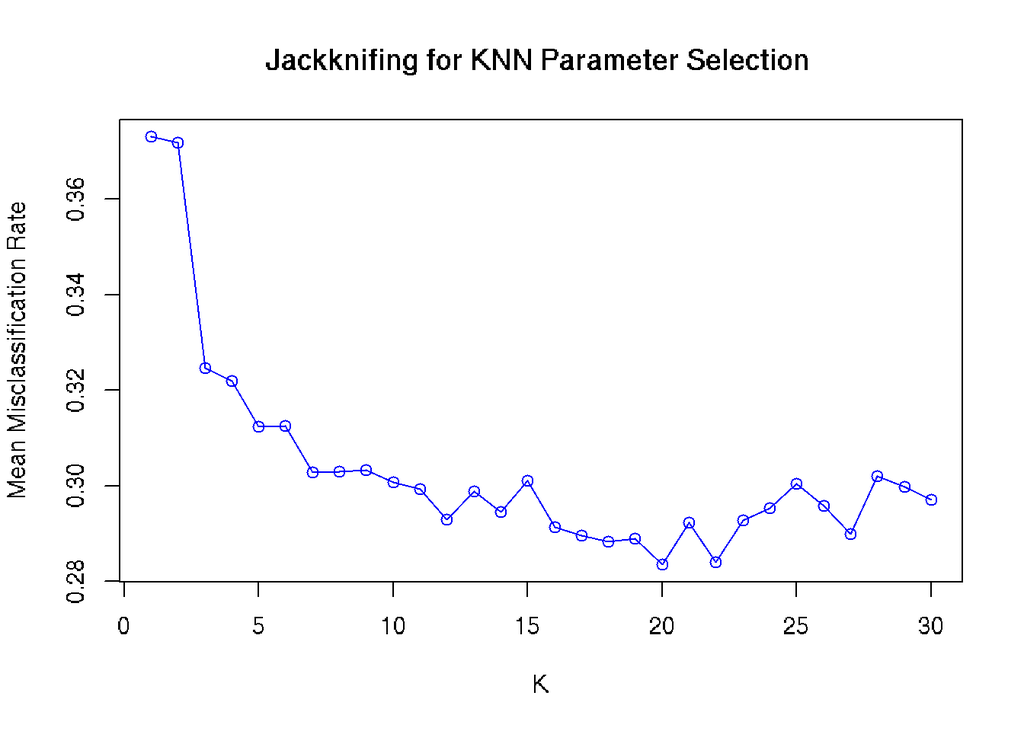

```r
R <- 200
misclassification_rates_jk <- matrix(NA, nrow = R, ncol = length(k_values))
n2 <- round(length(y_train) * 0.1)

for (j in 1:length(k_values)) {
  K <- k_values[j]

  for (i in 1:R) {
    index <- sample(length(y_train), n2)
    test_data <- X_train[index, ]
    train_data <- X_train[-index, ]

    yhat <- knn(
      train = train_data,
      test = test_data,
      cl = y_train[-index],
      k = K
    )

    misclassification_rates_jk[i, j] <- mean(yhat != y_train[index])  # Misclassification rate
  }
}

mean_misclassification_rates_jk <- colMeans(misclassification_rates_jk)

plot(k_values, mean_misclassification_rates_jk, type = "o", col = "blue", pch = 1, lty = 1,xlab = "K", ylab = "Mean Misclassification Rate",main = "Jackknifing for KNN Parameter Selection ")
```

6. Rewrite/reorganise your code so that each repetition can be carried out independently. Perform the Jackknifing selection of K(=1,2,…,30) using parallel computing, with function mclapply().

```r
perform_jackknifing <- function(K, R, n2, y_train, X_train) {
  misclassification_rates <- numeric(R)
  for (i in 1:R) {
    index <- sample(length(y_train), n2)
    test_data <- X_train[index, ]
    train_data <- X_train[-index, ]
    yhat <- knn(train = train_data,
                test = test_data,
                cl = y_train[-index],
                k = K)
    misclassification_rates[i] <- mean(yhat != y_train[index])  # Misclassification rate
  }
return(mean(misclassification_rates))
}

cores_to_test <- c(1, 5, 10, 20)
execution_times <- numeric(length(cores_to_test))

for (i in seq_along(cores_to_test)) {
  cores <- cores_to_test[i]
  cat("Testing with", cores, "cores...\n")
  start_time <- Sys.time()
  mean_misclassification_rates_jk_p <- mclapply(
    k_values,
    perform_jackknifing,
    R = R,
    n2 = n2,
    y_train = y_train,
    X_train = X_train,
    mc.cores = cores)

  end_time <- Sys.time()
  execution_times[i] <- as.numeric(end_time - start_time, units = "secs")
}
```

```
## Testing with 1 cores...
## Testing with 5 cores...
## Testing with 10 cores...
## Testing with 20 cores...
```

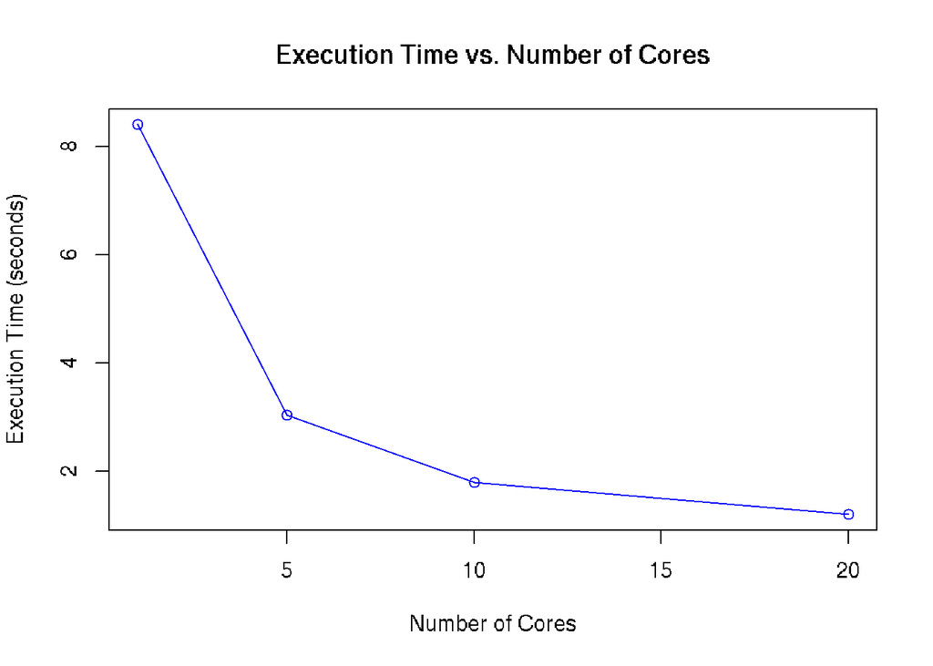

```r
plot(cores_to_test, execution_times, type = "o", col = "blue", pch = 1, lty = 1,xlab = "Number of Cores", ylab = "Execution Time (seconds)",main = "Execution Time vs. Number of Cores")
```

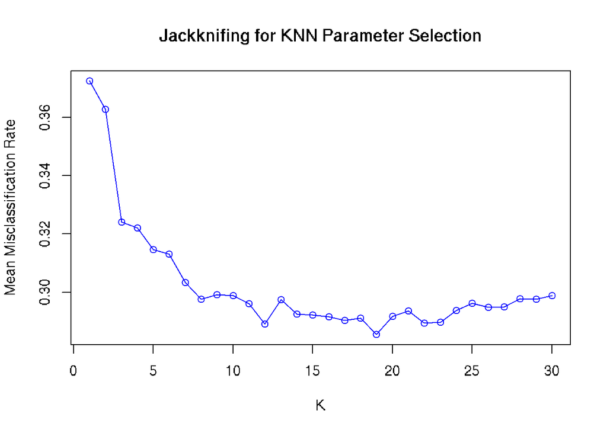

```r
plot(k_values, mean_misclassification_rates_jk_p, type = "o", col = "blue", pch = 1, lty =1,xlab = "K", ylab = "Mean Misclassification Rate",main = "Jackknifing for KNN Parameter Selection")
```

**Regression Trees**

7. Fit an unpruned regression tree with rpart (using cp=0.005) to the Abalone data and plot it (as clearly as you can, by adjusting the dimension of the diagram in your R Markdown file).

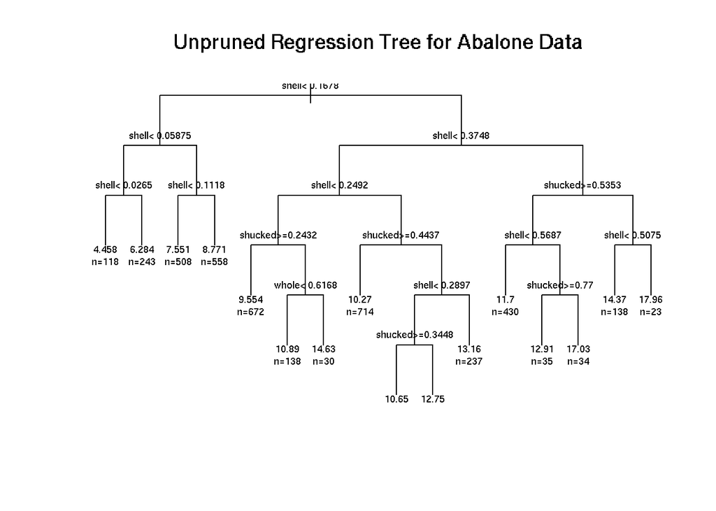

```r
train_data <- Abalone[1:1000, ]
test_data <- Abalone[-(1:1000), ]

set.seed(769)
tree_abalone <- rpart(rings ~ . - sex, data = Abalone, cp = 0.005)
plot(tree_abalone, uniform = TRUE, main = "Unpruned Regression Tree for Abalone Data")
text(tree_abalone, use.n = TRUE, cex = 0.6)
```

```r
(tree_abalone$variable.importance)[1:4]
```

```
##    shell    whole diameter   length
## 19318.18 17313.58 15470.19 15323.64
```

The variable.importance values provided represent the importance of each feature (or variable) in the unpruned regression tree. These values indicate how much each feature contributes to the overall decision-making process in the tree. A higher variable importance value suggests that a feature is more important in determining the target variable, “rings” in this case.These four variables capture critical aspects of Abalone’s physical characteristics, including size, age, and shell thickness, which are all related to the number of rings they have. The tree identifies these variables as the most important splits because they provide meaningful information for categorizing Abalone samples into groups with different ring counts. This allows the unpruned regression tree to make accurate predictions based on these key features.

8. Find the solutions to the following questions from the unpruned tree (without using code).
1. What is the variation (TSS) reduction by the split at the root node?

```r
tree_abalone$cptable
```

```
##             CP nsplit rel error    xerror       xstd
## 1  0.282174367      0 1.0000000 1.0004151 0.03219326
## 2  0.054323129      1 0.7178256 0.7284249 0.02609536
## 3  0.038904242      2 0.6635025 0.6793034 0.02370007
## 4  0.021426884      3 0.6245983 0.6410116 0.02327477
## 5  0.020954883      5 0.5817445 0.6194259 0.02246378
## 6  0.014396426      6 0.5607896 0.6002401 0.02178490
## 7  0.012457888      7 0.5463932 0.5838544 0.02096839
## 8  0.009108715      8 0.5339353 0.5775729 0.02072981
## 9  0.008344936      9 0.5248266 0.5620415 0.02029505
## 10 0.007948941     10 0.5164816 0.5601803 0.02028621
## 11 0.007310123     11 0.5085327 0.5596656 0.02031261
## 12 0.006727722     12 0.5012226 0.5510009 0.02006084
## 13 0.006102958     13 0.4944949 0.5434834 0.01982983
## 14 0.005843017     14 0.4883919 0.5418445 0.01984338
## 15 0.005000000     15 0.4825489 0.5328804 0.01954436
```

TSS Reduction = Error at Root Node - Error After First Split = 1.0000000 - 0.7178256 = 0.2821744

3. In which hyper-rectangular region, the mean number of rings is the largest?

9. Find the pruned tree, using 1 SE-rule, and plot it (as clearly as you can). Further, what did you find for the optimal value of the complexity parameter? What are the training and test errors (MSE), for the unpruned and pruned trees?

[figure not shown]

```r
pruned_tree <- prune(tree_abalone, cp = 0.005)
plot(pruned_tree)
text(pruned_tree)
```

```r
optimal_cp <- pruned_tree$cptable[which.min(pruned_tree$cptable[, "xerror"]), "CP"]
print(paste("Optimal CP:", optimal_cp))
```

```
## [1] "Optimal CP: 0.005"
```

```r
 mse_train_unpruned <- mean((train_data$rings - predict(tree_abalone, newdata = train_data))^2)
mse_test_unpruned <- mean((test_data$rings - predict(tree_abalone, newdata = test_data))^2)

y_train_pred <- predict(pruned_tree, newdata = train_data)
y_test_pred <- predict(pruned_tree, newdata = test_data)
mse_train_pruned <- mean((train_data$rings - y_train_pred)^2)
mse_test_pruned <- mean((test_data$rings - y_test_pred)^2)

cat("Optimal Complexity Parameter:", optimal_cp, "\n")
```

```
## Optimal Complexity Parameter: 0.005
```

```r
cat("Training Error (MSE) - Unpruned Tree:", mse_train_unpruned, "\n")
```

```
## Training Error (MSE) - Unpruned Tree: 4.912185
```

```r
cat("Test Error (MSE) - Unpruned Tree:", mse_test_unpruned, "\n")
```

```
## Test Error (MSE) - Unpruned Tree: 5.047393
```

```r
cat("Training Error (MSE) - Pruned Tree:", mse_train_pruned, "\n")
```

```
## Training Error (MSE) - Pruned Tree: 4.912185
```

```r
cat("Test Error (MSE) - Pruned Tree:", mse_test_pruned, "\n")
```

```
## Test Error (MSE) - Pruned Tree: 5.047393
```

**Summary**

10. Write a summary of the entire report.

In this lab, we worked with the Abalone dataset obtained from the UCI Machine Learning Repository. The dataset contains information about abalones, and our main goal was to perform classification and regression tasks using various techniques and methods in R.

**Data Overview and Preprocessing -** We loaded the Abalone dataset, which includes features like sex, length, diameter, height, and more.We transformed the dataset for classification by creating a factor class based on the “rings” variable, dividing it into three classes: [0,8], (8,12], and (12,Inf].We observed the need for standardizing or normalizing the numerical attributes, which is a common preprocessing step to ensure consistent scales for features.Also, we see that the “rings” variable has a right-skewed distribution, indicating that it’s not symmetric.